# GWAS Simulation: Microbial Methane Production

Author

Nibia

Published

October 2, 2026

## **🧬 Intro to Genome-Wide Association Studies 🧬**

Genome-Wide Association Studies (GWAS) help identify genetic variants linked to traits. In this case, we’ll explore **methane production in microbes** by simulating genetic data.

#### **Key GWAS Words/Concepts**

- *Genetic variation:* Most of the DNA from organisms of the same species is identical, however the parts where the DNA sequences differ are called genetic variants oe *SNP*.

[figure not shown]

*Society for Mucosal Immunology*

- *Genotype:* The specific DNA sequence of an individual, can refer to alleles or variants.
- *Allele:* One of two or more alternative forms of a gene.
  - *Homozygous:* Same allele
  - *Heterozygus:* Different alleles
- *Phenotype:* The trait represented as a result of the genotype.

From the introduction

#### **Typical GWAS model looks like this:**

$$E[\mathbf{y} \mid \mathbf{X}] =\boldsymbol\beta_0 + \boldsymbol\beta_1 \mathbf{X}$$

where:  
**y** is the trait  
**X** is the number of minor alleles

**Note**

**Fun fact:** Microbial Genome Associated Studies are often refer to mGWAS in the literature!

For the microbe nerds, this GWAS simulation will not fulfill all our current understanding of prokaryotic DNA and/or the most appropaite data for bacterial DNA. I will be using methods used on human GWAS. However, I wanted to share how bacterial DNA differs from human DNA:

##### **- No Chromosome Pairs:**

Humans have diploid genomes (two copies of each chromosome, so SNPs are 0, 1, or 2 based on allele copies). Bacteria are haploid (one circular chromosome), so they only have one allele per locus (0 or 1).

##### **- SNP Representation:**

In bacteria, a SNP is typically a single base change in a conserved region of the genome (A → G, C → T, etc.). Instead of 0, 1, 2 (homozygous reference, heterozygous, homozygous alternative) like in humans, bacterial SNPs are usually binary (present or absent at a given site).

##### **- Horizontal Gene Transfer (HGT):**

Bacteria can share genetic material through processes like conjugation, transformation, and transduction. This means that SNPs may spread across different bacterial strains in ways that are different from human inheritance.

##### **- Linkage Disequilibrium (LD) is Different:**

Because bacteria reproduce asexually (clonal reproduction), SNPs are often highly linked and don’t shuffle in the same way as in sexually reproducing species.

\  
Scientist working on mGWAS, reference human GWAS heavily. \ In the paper, *Microbial genome-wide association studies: lessons from human GWAS* (2016), they summarized some of the advancement for the time: \ - With more microbe genomes available, scientists can now use GWAS to study things like antibiotic resistance and how diseases spread. \ - Microbe populations are tricky to study due to their diversity and complex genetics, so better tools are needed to make progress. \ - Combining data from both host and microbe genomes could reveal how they interact, opening up exciting new research areas. \ >Power, R., Parkhill, J. & de Oliveira, T. Microbial genome-wide association studies: lessons from human GWAS. Nat Rev Genet 18, 41–50 (2017). https://doi.org/10.1038/nrg.2016.132 \ Most of the literature that I found covered mGWAS throught the lens of public health microbiology.

## **🦠 Simulating Microbial Data 🦠**

We will generate:

1. **1000 microbes** with **random SNPs** (0, 1, 2 copies of a minor allele).
2. A binary **“High Methane Producer”** trait influenced by a SNP.

```r
n <- 1000   # number of microbes
num_snps <- 5  # number of SNPs

# Function to generate SNPs based on minor allele frequency

generate_snp_maf <- function(n, maf, major = "A", minor = "G") {
  allele1 <- ifelse(runif(n) < maf, minor, major)   # generate first allele (major/minor based on MAF)
  allele2 <- ifelse(runif(n) < maf, minor, major) #  # generate second allele independently
  paste0(allele1, "/", allele2)   # genotype in
}

# minor allele frequencies
maf_values <- c(0.6, 0.8, 0.2, 0.4, 0.1)

# create SNP dataset with MAF????
snp_data <- data.frame(
  ID = 1:n,
  SNP1 = generate_snp_maf(n, maf_values[1], "A", "G"),
  SNP2 = generate_snp_maf(n, maf_values[2], "C", "T"),
  SNP3 = generate_snp_maf(n, maf_values[3], "G", "A"),
  SNP4 = generate_snp_maf(n, maf_values[4], "T", "C"),
  SNP5 = generate_snp_maf(n, maf_values[5], "A", "G")
)

# View first few rows
head(snp_data)
```

```
  ID SNP1 SNP2 SNP3 SNP4 SNP5
1  1  A/A  T/T  G/G  C/C  A/A
2  2  G/A  C/C  G/G  C/C  A/A
3  3  A/G  T/T  A/G  C/T  A/A
4  4  G/A  T/T  G/G  C/T  A/A
5  5  A/A  T/T  A/G  T/C  A/A
6  6  A/A  T/C  G/A  T/T  A/A
```

- *Why do we have two letters in each SNP in Human Genome?*  
  Humans are diploid organisms, meaning we inherit one copy of each chromosome from our mother and one from our father, resulting in two alleles.

## **📌 Converting SNPs to Numeric Genotypes (0, 1, 2) 📌**.

To analyze GWAS data, we **count the number of minor alleles** per individual. In this example, we will be determining which is the minor allele in this population of microbes.

```r
# SNPs from bases to numbers based on the minor allele numerically
convert_to_numeric <- function(snp, minor_allele) {
  sapply(snp, function(x) sum(unlist(strsplit(x, "/")) == minor_allele)) # count occurrences of the minor allele
}

# determining minor allele in each SNP and assigning it to
snp_numeric <- snp_data %>%
  mutate(
    SNP1_numeric = convert_to_numeric(SNP1, "G"),
    SNP2_numeric = convert_to_numeric(SNP2, "T"),
    SNP3_numeric = convert_to_numeric(SNP3, "A"),
    SNP4_numeric = convert_to_numeric(SNP4, "C"),
    SNP5_numeric = convert_to_numeric(SNP5, "G")
  ) %>%
  select(ID, ends_with("_numeric"))
head(snp_numeric)
```

```
  ID SNP1_numeric SNP2_numeric SNP3_numeric SNP4_numeric SNP5_numeric
1  1            0            2            0            2            0
2  2            1            0            0            2            0
3  3            1            2            1            1            0
4  4            1            2            0            1            0
5  5            0            2            1            1            0
6  6            0            1            1            0            0
```

```r
#determining SNP associated with trait
n <- nrow(snp_numeric) # calculate the number of individuals
y <- 3 * snp_numeric[,'SNP2_numeric'] + rnorm(n, 0, 1) # y = 2 * x + e

# look at the first few simulated trait values
head(y)
```

```
       T/T        C/C        T/T        T/T        T/T        T/C
 6.2809732 -0.2473763  6.5676564  5.8578841  6.6627146  4.9142788
```

## **🧮 Part 4: Quality Control 🧮**

We’re not going to be able to detect an association between our trait and any of the SNPs that have a MAF of zero (also known as *monomorphic* SNPs).

In our case, we stablished the MAFs all to be above O. Therefore we do not need to perform this quality control step.

## **🧬 Part 5: GWAS Analysis 🧬**

Now that we have numerical genotypes and a simulated trait, we can run a genome-wide association study (GWAS) to test which SNPs are associated with methane production.

### 1️⃣ Running Logistic Regression GWAS

We’ll use logistic regression to test whether each SNP is significantly associated with the high methane producer trait.

```r
# y to a binary trait (1 = high methane producer, 0 = low)
y_binary <- as.numeric(y > median(y))  # Median split to define high/low producers

#  logistic regression for each SNP
run_gwas <- function(snp_col) {
  model <- glm(y_binary ~ snp_numeric[[snp_col]], family = binomial) # Logistic regression
  tidy(model) %>% filter(term != "(Intercept)")  # Extract SNP results (skip intercept)
}

gwas_results <- map_dfr(names(snp_numeric)[-1], run_gwas, .id = "SNP")

gwas_results
```

```
# A tibble: 5 × 6
  SNP   term                   estimate std.error statistic  p.value
  <chr> <chr>                     <dbl>     <dbl>     <dbl>    <dbl>
1 1     snp_numeric[[snp_col]]   0.0671    0.0916     0.732 4.64e- 1
2 2     snp_numeric[[snp_col]]   5.03      0.371     13.6   6.56e-42
3 3     snp_numeric[[snp_col]]  -0.168     0.112     -1.50  1.33e- 1
4 4     snp_numeric[[snp_col]]   0.105     0.0901     1.17  2.42e- 1
5 5     snp_numeric[[snp_col]]   0.0308    0.143      0.215 8.30e- 1
```

### 2️⃣ Adjusting for Multiple Testing (Bonferroni)

Because we are testing multiple SNPs, we need to adjust our p-values to reduce false positives.

#### Bonferroni Connection

The significance level is the probability that a given test will incorrectly find a difference in the sample that is not present in the population (false positive).

$$Bonferroni\ Corrected\ p-value\ =\dfrac{\alpha}{n}$$
where:

$$\alpha$$
is the original p-value
$$n$$
is the number of tests

```r
# Bonferroni correction
gwas_results <- gwas_results %>%
  mutate(p_adj = p.value * nrow(gwas_results))

gwas_results %>%
  arrange(p.value)
```

```
# A tibble: 5 × 7
  SNP   term                   estimate std.error statistic  p.value    p_adj
  <chr> <chr>                     <dbl>     <dbl>     <dbl>    <dbl>    <dbl>
1 2     snp_numeric[[snp_col]]   5.03      0.371     13.6   6.56e-42 3.28e-41
2 3     snp_numeric[[snp_col]]  -0.168     0.112     -1.50  1.33e- 1 6.64e- 1
3 4     snp_numeric[[snp_col]]   0.105     0.0901     1.17  2.42e- 1 1.21e+ 0
4 1     snp_numeric[[snp_col]]   0.0671    0.0916     0.732 4.64e- 1 2.32e+ 0
5 5     snp_numeric[[snp_col]]   0.0308    0.143      0.215 8.30e- 1 4.15e+ 0
```

### 3️⃣ Visualizing GWAS Results

We’ll use a Manhattan plot to visualize SNP associations and a QQ plot to check for inflation of p-values.

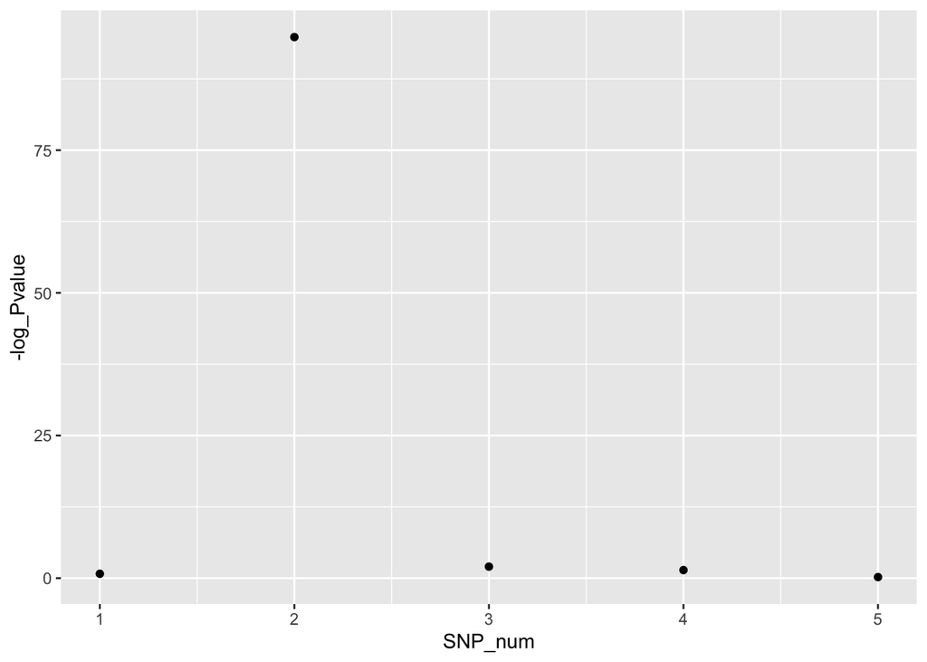

```r
# prepare for graphing the Manhattan plot
gwas_plot_data <- gwas_results %>%
  mutate(SNP_num = row_number())
gwas_plot_data <- gwas_plot_data %>%
  mutate(log_Pvalue = log(p.value))


ggplot(gwas_plot_data, aes(x= SNP_num, y= -log_Pvalue))+
  geom_point()
```

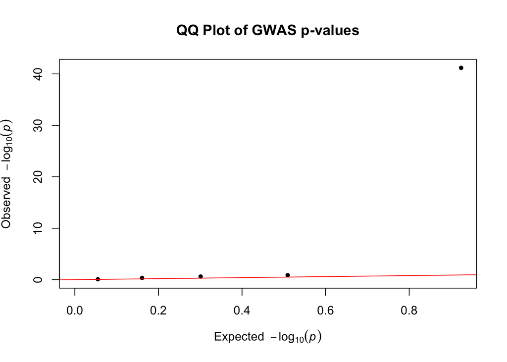

```r
# QQ plot
qqman::qq(gwas_results$p.value, main = "QQ Plot of GWAS p-values")
```

Since we are only working with 5 SNP, our Manhattan plot looks pretty sad. Each SNP belong to a specific location.